# ДЗ_3_Читадзе

2024-03-26

## Тема:

Расчет описательных статистик.

## Цель:

Научиться считать описательные статистики для количественной и категориальной переменных, строить доверительный интервал, а также графики плотности вероятности.

## Описание ДЗ

В RStudio создайте RMarkdown-файл и загрузите датасет pima. В первых двух заданиях вам необходимо посчитать описательные статистики. Для количественной переменной рассчитайте число наблюдений, среднее, стандартное отклонение, 1-й и 3-й квартили, минимум и максимум. Для категориальной переменной определите абсолютную и относительные частоты.

```r
library(tidyverse)
library(readxl)
```

```r
# Загружеам и читаем  датасет для работы
df <- read_excel(path = 'pima.xlsx')
head(df)
```

```
## # A tibble: 6 × 9
##   pregnant glucose pressure triceps insulin  mass pedigree   age diabetes
##      <dbl>   <dbl>    <dbl>   <dbl>   <dbl> <dbl>    <dbl> <dbl> <chr>
## 1        6     148       72      35       0  33.6    0.627    50 pos
## 2        1      85       66      29       0  26.6    0.351    31 neg
## 3        8     183       64       0       0  23.3    0.672    32 pos
## 4        1      89       66      23      94  28.1    0.167    21 neg
## 5        0     137       40      35     168  43.1    2.29     33 pos
## 6        5     116       74       0       0  25.6    0.201    30 neg
```

```r
# Выаолняем необходимы преобразования с данными
df <- na.omit(df)
df <- df %>%
    mutate_at(vars(diabetes), as.factor)
```

## Задание 1

Рассчитайте описательные статистики для переменных glucose, pressure, mass.

```r
# Расчет основных статистик для каждой переменной:
glucose_stat <- summary(df$glucose)
pressure_stat <- summary(df$pressure)
mass_stat <- summary(df$mass)
```

```r
# Расчет стандартного отклонения для каждой переменной:
glucose_sd <- sd(df$glucose, na.rm = TRUE)
pressure_sd <- sd(df$pressure, na.rm = TRUE)
mass_sd <- sd(df$mass, na.rm = TRUE)
```

```r
glucose_stat
```

```
##    Min. 1st Qu.  Median    Mean 3rd Qu.    Max.
##     0.0    99.0   117.0   120.9   140.2   199.0
```

```r
pressure_stat
```

```
##    Min. 1st Qu.  Median    Mean 3rd Qu.    Max.
##    0.00   62.00   72.00   69.11   80.00  122.00
```

```r
mass_stat
```

```
##    Min. 1st Qu.  Median    Mean 3rd Qu.    Max.
##    0.00   27.30   32.00   31.99   36.60   67.10
```

```r
glucose_sd
```

```
## [1] 31.97262
```

```r
pressure_sd
```

```
## [1] 19.35581
```

```r
mass_sd
```

```
## [1] 7.88416
```

## Задача 2

Рассчитайте описательную статистику для переменной diabetes. Создайте на основе переменной age новую переменную age_group, которая будет отражать следующие возрастные группы: 21–35, 36–49 и 50+. Посчитайте описательную статистику для новой переменной.

```r
# Абсолютные частоты
absolute_freq <- table(df$diabetes)
print(absolute_freq)
```

```
##
## neg pos
## 500 268
```

```r
# Относительные частоты
relative_freq <- prop.table(absolute_freq) * 100
print(relative_freq)
```

```
##
##      neg      pos
## 65.10417 34.89583
```

```r
# Создание переменной age_group
df<- df %>%
  mutate(age_group = ifelse(age <= 35, "21-35",
  ifelse(age <= 49, "36-49", "50+")))
df <- mutate(df, age_group = as.factor(age_group))
```

```r
# Создание таблицы абсолютных частот
age_abs <- table(df$age_group)
# Вычисление относительных частот в процентах
age_rel <- (age_abs / length(df$age_group)) * 100

age_abs
```

```
##
## 21-35 36-49   50+
##   498   181    89
```

```r
age_rel
```

```
##
##    21-35    36-49      50+
## 64.84375 23.56771 11.58854
```

## Задача 3

Определите 90% доверительный интервал для переменной pedigree.

```r
# Вычисление среднего значения переменной pedigree
mean_ped <- mean(df$pedigree)
# Вычисление стандартного отклонения переменной pedigree
sd_ped <- sd(df$pedigree)
# Вычисление стандартной ошибки среднего переменной pedigree
se_ped <- sd_ped / sqrt(length(df$pedigree))
```

```r
# Вычисляем доверительный интервал для среднего значения переменной pedigree
alpha <- 0.1
df1 <- length(df$pedigree) - 1
t <- qt(alpha / 2, df1, lower.tail = F)

pedigree_inter <- c(mean_ped- t * se_ped,
                      mean_ped + t * se_ped)
pedigree_inter
```

```
## [1] 0.4521870 0.4915656
```

## Задача 4

Постройте график плотности вероятности для переменной glucose и отметьте на нем среднее значение. Для той же переменной постройте гистограмму. Постройте два ящика с усами для значений pos и neg соответственно переменной diabetes.

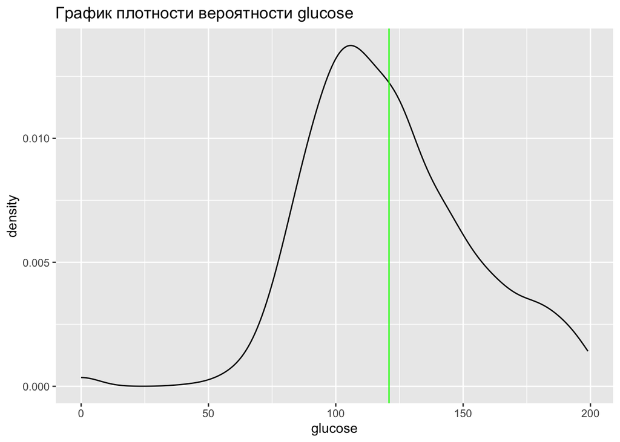

```r
dens <- ggplot(data = df) +
  geom_density(aes(glucose)) +
  geom_vline(xintercept = mean(df$glucose), color = 'green') +
  labs(title = "График плотности вероятности glucose")
print(dens)
```

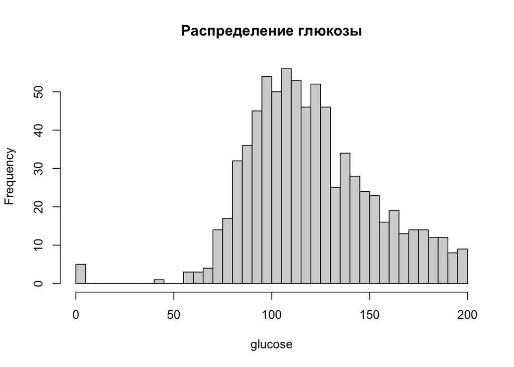

```r
hist_gluc <- hist(df$glucose,
  breaks = 60,
  main = "Распределение глюкозы",
  xlab = "glucose")
```

```r
print(hist_gluc)
```

[output not shown]

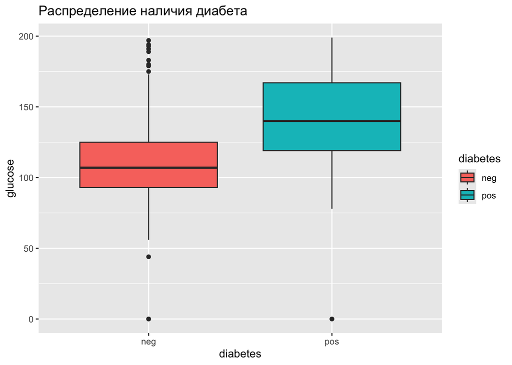

```r
box <- ggplot(data = df) +
  geom_boxplot(aes(diabetes, glucose, fill = diabetes)) +
  labs(title = "Распределение наличия диабета")
print(box)
```

## Задача 5

Постройте на одном графике две диаграммы рассеяния для наличия или отсутствия диабета. По оси X представьте значения обхвата трицепса, а по оси Y — массу тела. Выполните окрашивание, заливку и группирование по переменной diabetes.

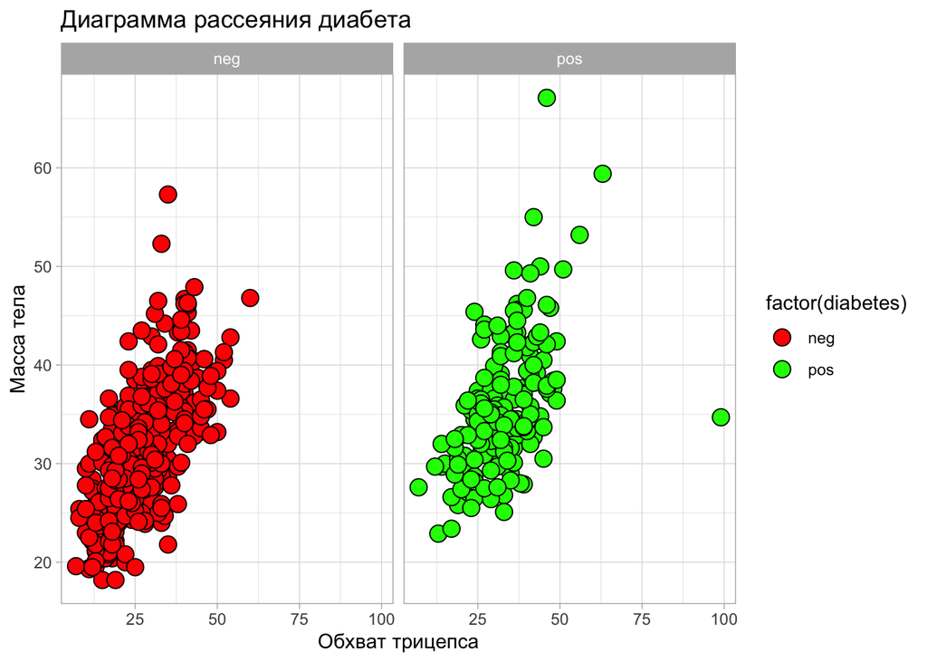

```r
# Удаление строк, где обхват трицепса или масса тела равны нулю
df_clean <- subset(df, triceps != 0 & mass != 0)

# Создание графика с фасеткой
facet <- ggplot(data = df_clean,
                aes(x = triceps, y = mass, fill = factor(diabetes))) +
  geom_point(color = "black", shape = 21, size = 4) +
  scale_fill_manual(values = c("red", "green")) +
  facet_grid(. ~ diabetes) +
  labs(title = "Диаграмма рассеяния диабета",
       x = "Обхват трицепса", y = "Масса тела") +
  theme_light()

print(facet)
```